# 第14回 分散分析（2）：多重比較と分析結果のまとめ方

行動計量学（行動科学分析法入門）

小野原 彩香

令和8年度

## 本日の目標

1. 多重比較の必要性と Tukey HSD 法の考え方を理解する
2. Rで多重比較を実行し，どの群間に差があるかを特定できる
3. 分散分析から多重比較までの結果を統合してレポートにまとめられる
4. **発展**：補正がなぜ全体の誤り率を守れるのかを，式で説明できる

## 準備：パッケージの読み込み

この回のコードは，すべて `tidyverse` を読み込んだ状態で動きます。 RStudioを起動したら，**まずこれを実行してください。**

```r
library(tidyverse)
```

> 毎回必要です。読み込まないまま `filter()` や `ggplot()` を使うと， 「関数が見つかりません」というエラーになります。

## 1. 多重比較とは

### 分散分析の後に必要なこと

分散分析（ANOVA）で「少なくとも1組の群に有意差がある」とわかっても， **「どの群とどの群が異なるのか」**はわかりません。

→ **多重比較（post-hoc test）** でペアごとの差を検定します。

### なぜ専用の方法が必要か？

単純な t検定の繰り返しでは第一種の過誤率が膨らむ（第13回で解説）ため， 検定全体の誤り率を制御する方法を使います。

## 2. 代表的な多重比較法

| 方法 | 特徴 | Rの関数 |
| --- | --- | --- |
| **Tukey HSD** | 全ペア比較，バランスのとれた設計に適す | `TukeyHSD()` |
| Bonferroni | 保守的，検定回数で α を割る | `pairwise.t.test(..., p.adjust="bonferroni")` |
| Holm | Bonferroni より検出力が高い | `pairwise.t.test(..., p.adjust="holm")` |
| Scheffé | 任意の対比を検定，最も保守的 | 専用パッケージ |

> 本授業では **Tukey HSD 法** を中心に扱います。

**導出①**：ボンフェローニ補正はなぜ効くのか ―― 独立を仮定しない不等式**

$m$ 個の比較を行い，$i$ 番目の比較で偽陽性を出す事象を $A_i$ と書きます。守りたいのは「どれか1つでも偽陽性を出す」確率です。

$$\mathrm{FWER} = P(A_1 \cup A_2 \cup
\cdots \cup A_m)$$

ここで**ブールの不等式**を使います。和事象の確率は，各事象の確率を単純に足したものを超えません。重なっている部分を二重に数えるぶん，足し算のほうが大きいか等しいからです。

$$P(A_1 \cup \cdots \cup A_m) \le
\sum_{i=1}^{m} P(A_i)$$

各比較の水準を $\alpha/m$ にしておけば，右辺は

$$\sum_{i=1}^{m} \frac{\alpha}{m} = m
\cdot \frac{\alpha}{m} = \alpha$$

となり，$\mathrm{FWER} \le \alpha$ が保証されます。

> **第13回の式との違いに注目してください。** 第13回の $1-(1-\alpha)^k$ は，$k$ 回の検定が**独立だと仮定した等式**でした。一方こちらは**不等式**で，検定どうしがどう絡み合っていても成り立ちます。総当たり比較のように同じ群のデータを共有していても構いません。何も仮定せずに守れるのが，ボンフェローニの強みです。

> 代償は**保守的**になることです。不等式は「最悪でもこれ以下」としか言っていないので，実際の誤り率は $\alpha$ よりかなり小さくなりがちです。そのぶん，本当にある差を見逃しやすくなります。

**数値で確かめる**：3群なら比較は $m = 3$ 組なので，各比較を $0.05/3 = 0.0167$ で判定することになります。`iris` の versicolor 対 virginica では，無補正の $p = 2.77 \times 10^{-9}$ が補正後は $8.30 \times 10^{-9}$ になります。ちょうど3倍です。

**使った数学**：ブールの不等式（和事象の確率は各確率の和以下）。独立性はどこにも使っていません。

**導出②**：Tukey HSD は「いちばん離れた2つ」を基準にする**

ボンフェローニは，比較どうしの関係を一切使わずに安全側で抑える方法でした。Tukey HSD は別の道を通ります。

$k$ 個の群があり，すべてのペアを比べるとします。ここで考えてみてください。**どれか1つでも偽陽性を出してしまう**のは，どういう場合でしょうか。それは，ペアの中で**いちばん差が大きく出たもの**が，しきい値を超えてしまう場合です。

つまり守るべき相手は，個々のペアではなく，**最大の平均と最小の平均の差**ただ1つです。

$$\max_j \bar{x}_j - \min_j
\bar{x}_j$$

この「最大と最小の幅」が，帰無仮説のもとでどれくらいの大きさになるか。その分布を**スチューデント化された範囲**（studentized range，記号 $q$）と呼びます。$q$ の上位 $5\%$ 点をしきい値にすれば，最大の差が守られ，したがって**すべてのペアが同時に守られます**。

$$HSD = q_{\alpha}(k,\ df) \times
\sqrt{\frac{MS_{群内}}{n}}$$

**数値で確かめる**：`iris` は $k=3$，$df=147$，$MS_{群内}=0.2650$，各群 $n=50$ です。$q_{0.05}(3,\ 147) = 3.3484$ なので

$$HSD = 3.3484 \times \sqrt{0.2650/50} =
0.2438$$

平均差がこれを超えれば有意です。実際の3つの平均差は $0.930$，$1.582$，$0.652$ で，いずれも大きく上回っています。

同じ条件でボンフェローニの最小有意差を計算すると $0.2493$ となり，Tukey の $0.2438$ よりわずかに大きい。つまり Tukey のほうが，小さい差でも有意と判定できます。臨界値を $t$ の尺度に揃えて比べると，ボンフェローニが $2.4217$，Tukey が $2.3677$ です。

**Tukey のほうが検出力が高いのは，比較どうしが無関係ではないことを利用しているからです。** ボンフェローニは「どんな絡み方をしていても大丈夫なように」と身構えて余裕を取りますが，Tukey は総当たり比較という具体的な状況での $q$ の分布を使うので，その余裕を削れます。

群の数が増えるほど，この差は広がります。

| 群数 $k$ | 比較数 $m$ | ボンフェローニ | Tukey |
| --- | --- | --- | --- |
| 3 | 3 | 2.4217 | 2.3677 |
| 5 | 10 | 2.8500 | 2.7619 |
| 10 | 45 | 3.3265 | 3.2129 |

上の表の臨界値は，いずれも自由度 $147$（`iris` と同じ）で計算したものです。

> **この $HSD$ の式は，各群の $n$ が等しい（バランス型）ことを使っています。** 分母の $\sqrt{MS_{群内}/n}$ に $n$ が1つしか出てこないのは，そのためです。 群のサイズが違う場合，Rの `TukeyHSD()` は自動的に $\sqrt{\dfrac{MS_{群内}}{2}\left(\dfrac{1}{n_i}+\dfrac{1}{n_j}\right)}$ に置き換えて計算します （**Tukey–Kramer法**）。演習3の `mtcars` は各群 11・7・14 名でサイズが違うので，こちらが使われます。

**使った数学**：最大値と最小値の差の分布という考え方。なお $q$ 分布そのものを導くのは，この科目の範囲外です。

**導出③**：ホルム法 ―― 段階的に条件を緩める**

表に挙げた**ホルム法**は，ボンフェローニを改良したものです。考え方は単純で，$p$ 値を小さい順に並べ，しきい値を段階的に緩めていきます。

$m$ 個の $p$ 値を小さい順に $p_{(1)} \le p_{(2)} \le \cdots \le p_{(m)}$ と並べ，

$$p_{(1)} \text{ は }
\frac{\alpha}{m}，\quad p_{(2)} \text{ は } \frac{\alpha}{m-1}，\quad
\dots，\quad p_{(i)} \text{ は } \frac{\alpha}{m-i+1}$$

と比べます。順に判定していき，初めて基準を満たさなかったところで止めて，それ以降はすべて有意ではないとします。

いちばん小さい $p$ 値に対する基準 $\alpha/m$ はボンフェローニと同じですが，2番目以降は分母が小さくなるぶん**基準が緩みます**。したがって，ボンフェローニで有意になるものはホルムでも必ず有意になり，その逆は成り立ちません。**同じ保証のもとで検出力だけが高い**ので，2つのうちならホルムを選んで困ることはありません。

**数値で確かめる**：`iris` の3つの比較のうち，versicolor 対 virginica は無補正の $p = 2.77 \times 10^{-9}$ が最大の $p$ 値です。ボンフェローニでは一律に3倍されて $8.30 \times 10^{-9}$ になりますが，ホルムでは分母が $m-i+1 = 1$ となるため $2.77 \times 10^{-9}$ のまま据え置かれます。

**使った数学**：$p$ 値を大きさの順に並べることと，段階的な判定。

## 3. Tukey HSD 法の実行

### 例：iris データ（3種のがく片の長さ）

```r
# 分散分析の実行（第13回の復習）
result_anova <- aov(Sepal.Length ~ Species, data = iris)
summary(result_anova)
```

```
##              Df Sum Sq Mean Sq F value Pr(>F)
## Species       2  63.21  31.606   119.3 <2e-16 ***
## Residuals   147  38.96   0.265
## ---
## Signif. codes:  0 '***' 0.001 '**' 0.01 '*' 0.05 '.' 0.1 ' ' 1
```

```r
# Tukey HSD 多重比較
result_tukey <- TukeyHSD(result_anova)
result_tukey
```

```
##   Tukey multiple comparisons of means
##     95% family-wise confidence level
##
## Fit: aov(formula = Sepal.Length ~ Species, data = iris)
##
## $Species
##                       diff       lwr       upr p adj
## versicolor-setosa    0.930 0.6862273 1.1737727     0
## virginica-setosa     1.582 1.3382273 1.8257727     0
## virginica-versicolor 0.652 0.4082273 0.8957727     0
```

### 結果の読み方

```
  Tukey multiple comparisons of means
    95% family-wise confidence level

Fit: aov(formula = Sepal.Length ~ Species, data = iris)

$Species
                      diff       lwr       upr   p adj
versicolor-setosa    0.930 0.6862273 1.1737727 0.0e+00
virginica-setosa     1.582 1.3382273 1.8257727 0.0e+00
virginica-versicolor 0.652 0.4082273 0.8957727 8.3e-09
```

| 列 | 意味 |
| --- | --- |
| `diff` | 平均差（後ろの群 − 前の群） |
| `lwr` / `upr` | 平均差の95%信頼区間の下限・上限（**ファミリー全体で95%**） |
| `p adj` | 調整済みp値（< .05 で有意） |

> **`p adj` の表示に注意。** 上2つは `0.0e+00` と出ていますが， 「ちょうど0」ではなく**表示できないほど小さい**という意味です。 3つ目の `8.3e-09` は $8.3 \times 10^{-9}$ で，これも十分小さい値です。 レポートには `p adj = 0` ではなく **`p < .001`** と書いてください。

> **`diff` の符号は行の名前が決めます。** `versicolor-setosa` は「versicolor の平均 − setosa の平均」です。 $0.930 > 0$ なので versicolor のほうが長い，と読みます。

> **信頼区間が「95%」である意味も，第10回とは少し違います。** ここでの95%は**3つの区間をまとめて**の信頼度（family-wise）です。 3本の区間が同時にすべて正しく真の差を含む確率が95%という意味で， そのぶん1本ずつの区間は，個別に作るより広くなっています。

## 4. Tukey HSD 結果の可視化

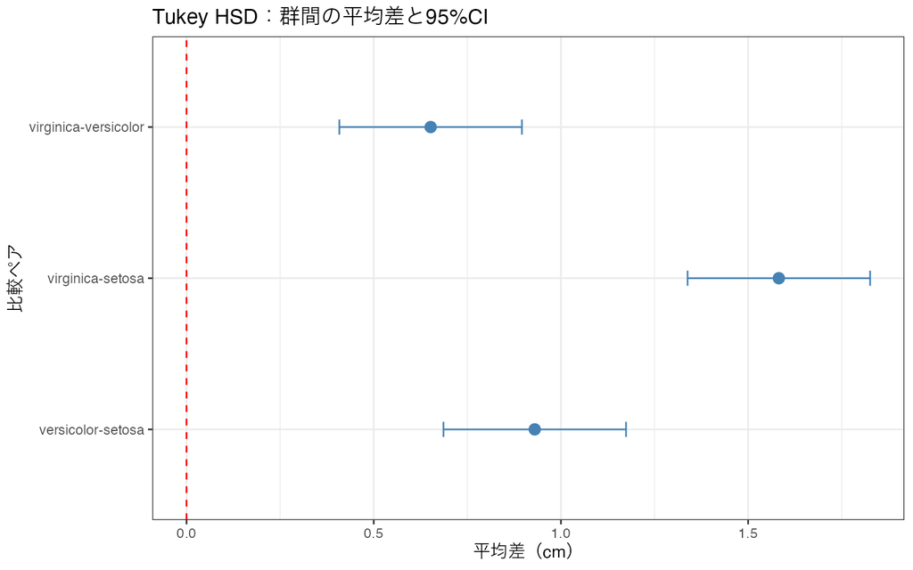

```r
# confint() でデータフレームに変換して描く
tukey_df <- as.data.frame(result_tukey$Species)
tukey_df$comparison <- rownames(tukey_df)

ggplot(tukey_df, aes(x = comparison, y = diff)) +
  geom_point(size = 3, color = "steelblue") +
  geom_errorbar(aes(ymin = lwr, ymax = upr), width = 0.1, color = "steelblue") +
  geom_hline(yintercept = 0, linetype = "dashed", color = "red") +
  labs(title = "Tukey HSD：群間の平均差と95%CI",
       x = "比較ペア", y = "平均差（cm）") +
  coord_flip() +
  theme_bw()
```

> 信頼区間が 0 をまたがっていなければ有意差あり。

## 5. 全体の結果をグラフで示す

### 有意差ブラケット付きの箱ひげ図

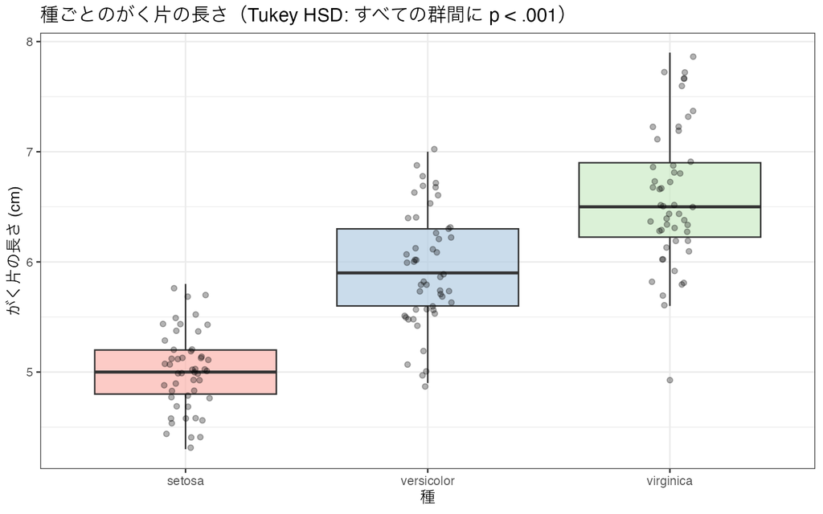

```r
# ggplot2で箱ひげ図を作成
p_box <- ggplot(iris, aes(x = Species, y = Sepal.Length, fill = Species)) +
  geom_boxplot(outlier.shape = NA, alpha = 0.7) +
  geom_jitter(width = 0.1, alpha = 0.3, size = 1.5) +
  scale_fill_brewer(palette = "Pastel1") +
  labs(title = "種ごとのがく片の長さ（Tukey HSD: すべての群間に p < .001）",
       x = "種", y = "がく片の長さ (cm)") +
  theme_bw() +
  theme(legend.position = "none")
p_box
```

## 6. 完全な分析フローのまとめ

### Step 1：記述統計

```r
iris |>
  group_by(Species) |>
  summarise(n = n(), M = mean(Sepal.Length), SD = sd(Sepal.Length)) |>
  mutate(across(where(is.numeric), ~ round(., 2)))
```

| Species | n | M | SD |
| --- | --- | --- | --- |
| setosa | 50 | 5.01 | 0.35 |
| versicolor | 50 | 5.94 | 0.52 |
| virginica | 50 | 6.59 | 0.64 |

### Step 2：前提条件の確認

```r
bartlett.test(Sepal.Length ~ Species, data = iris)
```

```
##
##  Bartlett test of homogeneity of variances
##
## data:  Sepal.Length by Species
## Bartlett's K-squared = 16.006, df = 2, p-value = 0.0003345
```

> **第13回で見たとおり，このデータは p = .0003 で等分散が成り立っていません。** それでも `aov()` → `TukeyHSD()` で進めるのは， 群ごとの $n$ が 50 ずつ等しく，分散のズレの影響が比較的小さいためです。 **$n$ が群によって大きく違い，かつ分散も違う場合は，この流れは安全ではありません。** その場合は `oneway.test()` と，等分散を仮定しない多重比較 （`pairwise.t.test(..., pool.sd = FALSE, p.adjust.method = "holm")`）を使ってください。

```r
# 等分散を仮定しない多重比較（参考）
pairwise.t.test(iris$Sepal.Length, iris$Species,
                pool.sd = FALSE, p.adjust.method = "holm")
```

```
##
##  Pairwise comparisons using t tests with non-pooled SD
##
## data:  iris$Sepal.Length and iris$Species
##
##            setosa  versicolor
## versicolor < 2e-16 -
## virginica  < 2e-16 1.9e-07
##
## P value adjustment method: holm
```

このデータでは，どちらで計算しても3組すべて有意という結論は変わりません。

### Step 3：分散分析

```r
result_anova <- aov(Sepal.Length ~ Species, data = iris)
summary(result_anova)
```

```
##              Df Sum Sq Mean Sq F value Pr(>F)
## Species       2  63.21  31.606   119.3 <2e-16 ***
## Residuals   147  38.96   0.265
## ---
## Signif. codes:  0 '***' 0.001 '**' 0.01 '*' 0.05 '.' 0.1 ' ' 1
```

### Step 4：多重比較

```r
TukeyHSD(result_anova)
```

```
##   Tukey multiple comparisons of means
##     95% family-wise confidence level
##
## Fit: aov(formula = Sepal.Length ~ Species, data = iris)
##
## $Species
##                       diff       lwr       upr p adj
## versicolor-setosa    0.930 0.6862273 1.1737727     0
## virginica-setosa     1.582 1.3382273 1.8257727     0
## virginica-versicolor 0.652 0.4082273 0.8957727     0
```

### Step 5：効果量

```r
ss <- anova(result_anova)[["Sum Sq"]]   # 1番目が群間，2番目が群内
round(ss[1] / sum(ss), 3)               # η²
```

```
## [1] 0.619
```

## 7. 結果の報告（論文・レポート形式）

> **方法**：3種のアヤメ（setosa, versicolor, virginica）のがく片の長さを 一元配置分散分析によって比較した。多重比較には Tukey HSD 法を用いた。

> **結果**：種の主効果が有意であった，*F*(2, 147) = 119.3, *p* < .001, η² = .62。 Tukey HSD 法による多重比較の結果， setosa と versicolor（*p* < .001），setosa と virginica（*p* < .001）， versicolor と virginica（*p* < .001）の間でそれぞれ有意差が認められた。

## 演習

### 演習1：多重比較の実行

`iris` データで `Petal.Length` の一元配置分散分析を実行し， Tukey HSD で多重比較を行ってください。

どの群間に有意差がありましたか？

```r
result <- aov(___ ~ ___, data = iris)
TukeyHSD(result)
```

### 演習2：視覚化

演習1の Tukey HSD の結果を，信頼区間のプロットで表示してください。

> ```r
> tukey_df <- as.data.frame(TukeyHSD(result)$Species)
> tukey_df$comparison <- rownames(tukey_df)
> ```

### 演習3：総合レポート（最終課題の練習）

以下の問いに対して，Step 1〜5 の分析フローを実行し， 結果を論文の「方法・結果」の節として1段落にまとめてください。

**問い**：`mtcars` データで，シリンダー数（`cyl`：4・6・8）によって 馬力（`hp`）に違いがあるかを検討してください。

1. 記述統計（平均・SD・n）
2. 箱ひげ図
3. 一元配置分散分析（`aov()`）
4. Tukey HSD
5. 効果量 η²
6. 結果の記述

### ⚠ `cyl` は数値のままでは分散分析になりません

> `mtcars$cyl` は 4・6・8 という**数値**の列です。そのまま `aov(hp ~ cyl, data = mtcars)` と書くと，Rは「4・6・8 という量」として扱い， **自由度1の回帰**を当てはめてしまいます（群の比較になりません）。 続けて `TukeyHSD()` を実行すると **「当てはめモデル中には因子がありません」というエラー**になります。

> 先に因子（factor）に変換してください。

```r
mtcars2 <- mtcars |> mutate(cyl_f = factor(cyl))
result  <- aov(hp ~ cyl_f, data = mtcars2)
summary(result)
TukeyHSD(result)
```

> `summary(result)` の `Df` が **2**（$= k-1$）になっていれば，正しく群比較になっています。 **1 になっていたら，`factor()` を忘れています。**

> **ヒント**：3組のうち1組だけ有意になりません。 「すべて有意」ではない結果をどう記述するかが，この演習の狙いです。 また各群の $n$ が 11・7・14 と違うので，導出②の **Tukey–Kramer法** が使われます。

## 本日のまとめ

- 分散分析で有意差が出た後，Tukey HSD で**どの群間か**を特定する
- `TukeyHSD()` で調整済みp値と信頼区間を確認
- 分析フローは「記述統計 → 前提確認 → ANOVA → 多重比較 → 効果量 → 報告」
- 結果の記述には F値・df・p値・η²・多重比較の結果を含める

## 宿題・予習

- 演習3（総合問題）を完成させ，スクリプトを保存する
- 次回（第15回）は**最終まとめと習熟度確認テスト（第3回）**です
- 第1〜14回の内容全体を見直しておいてください